# Breve introducción a R

José Roberto Bermúdez Barrientos

5/1/2020

Última actualización: 2020-05-06

Palabras clave: introducción a R, tutorial R principiantes, ordenar data frame, leer fasta

Bienvenid@ a R!

Recuerda que si tienes dudas, puedes escribirme a mi correo: jose.bermudez@cinvestav.mx

En ésta sesión vamos a aprender sobre:

- Conceptos básicos de R
- Leer tablas externas y explorar datos
- Leer archivos fasta dentro de R y una descripción de sus contenidos

##### Qué es R

R es un ambiente de software libre para hacer cómputo estadístico.

R es open source, lo que significa que su código está disponible, se puede modificar y se puede re-distribuir libremente.

##### Por qué utilizar R?

R es un lenguaje de alto nivel, esto quiere decir que al empezar a usar R, no hay necesidad de generar estructuras de datos como en otros lenguajes de programación de bajo nivel como C, ensamblador, u otros.

R goza actualmente de una gran popularidad entre personas que necesitan hacer análisis estadísticos en una gran diversidad de áreas (ciencias biológicas, economía, sport science, etc).

Esto ha favorecido el surgimiento de un gran número de usuarios y desarrolladores de paquetes para una infinidad de propósitos. Esto a su vez tiene como consecuencia que difícilmente tendrás que programar algo de cero.

Nosotros jugaremos un rol de usuario en vez de desarrollador la mayoría del tiempo.

Bioconductor es una iniciativa para compartir paquetes de R para analizar datos genómicos. https://www.bioconductor.org/

Al día 1 de Mayo de 2020, Bioconductor reporta 1903 paquetes. Wow!

##### Qué desventajas tiene R?

En ocasiones puede utilizar más memoria que otros lenguajes para ciertas tareas o usando algunas funciones (como por ejemplo cargar a memoria un archivo de alineación de RNA-Seq).

R no está hecho para funcionar como un manejador de páginas web como JavaScript, PHP, etc.

El competidor más grande de R para analizar datos genómicos es Python. Honestamente sé muy poco de Python y no me atrevería a hacer una comparativa a fondo entre los dos lenguajes. Pero si incursionan en la bioinformática, eventualmente llegará el día que tengan que usar un programa o paquetería hecha en Python.

##### Formas de ejecutar R

Existen distintas maneras de ejecutar R

- Desde la terminal: Si R está instalado en sus computadoras pueden abrir una terminal (Linux o Mac) y teclear R
- Desde RStudio
- Desde la terminal ejecutando scripts: Rscript mi_script.R, este tipo de uso de R es necesario en clusters de cómputo sin interfaz gráfica.

##### RStudio

RStudio es un entorno de desarrollo integrado (IDE, por sus siglas en inglés), que facilita el uso y desarrollo de código en R.

Tiene facilidades como autocompletar nombres de variables y funciones, poder ejecutar líneas de código específicas.

[figure not shown]

##### Interpretando esta página

A lo largo de esta página encontrarás recuadros como los que aparecen a continuación. Generalmente ocurren en pares, el primero de ellos es una porción de código que se ingresar a la consola de R directamente (parte inferior izquierda de RStudio) o se puede copiar a un script de R (parte superior izquierda de RStudio). El segundo recuadro representa la salida de la código ingresado en el primer recuadro. Así pues, al ingresar 1+1 dentro de R obtenemos 2.

```r
1+1
```

```
## [1] 2
```

##### Aritmética en R

Podemos hacer sumas y restas

```r
8-15
```

```
## [1] -7
```

Podemos hacer divisones

```r
(6+8)/2
```

```
## [1] 7
```

Multiplicaciones

```r
3*5
```

```
## [1] 15
```

Potencias

```r
2^3
```

```
## [1] 8
```

```r
# otra manera de expresar potencias
2**3
```

```
## [1] 8
```

##### Secuencias de números

Podemos obtener secuencias de números rápidamente con la siguente sintaxis NumeroInicial:NumeroFinal

```r
5:18
```

```
##  [1]  5  6  7  8  9 10 11 12 13 14 15 16 17 18
```

También podemos incluír números negativos, así como iniciar de un número mayor e ir hacia uno menor

```r
23:-4
```

```
##  [1] 23 22 21 20 19 18 17 16 15 14 13 12 11 10  9  8  7  6  5  4  3  2  1  0 -1
## [26] -2 -3 -4
```

##### Variables y objetos

Asignación de datos a variables

```r
x <- 2+1
```

Podemos ver el contenido de x

```r
x
```

```
## [1] 3
```

Nota: Podemos asignar algún contenido a una variable con <- o con =

```r
x <- 2+1
# es lo mismo que:
x = 2+1
```

Cuál de las dos asignaciones usar? Algunas personas recomiendan usar <- para hacer énfasis en que se trata de una asigación a un objeto y diferenciar las asignaciones a argumentos dentro de una función (ver más adelante). En realidad pueden usar la que gusten, algunas personas prefieren usar = ya que usa un solo carácter y <- usa dos caracteres

Para ver los objetos que tenemos

```r
ls()
```

```
## [1] "x"
```

Esto resultará familiar a usuarios de línea de comandos tipo Unix-like

Para borrar un objeto

```r
rm(x)
```

##### Cambiar de directorio y listar contenidos

Podemos obtener el directorio en el que estamos trabajando mediante la función getwd()

```r
getwd()
```

```
## [1] "/Users/beto/Dropbox/JRB/Teaching/Rmarkdowns"
```

Podemos cambiar el directorio de trabajo con setwd(“/directorio_deseado”)

```r
setwd("/home/usuario")
```

Podemos ver el contenido de un directorio de interés con la función list.files()

```r
list.files("/")
```

```
##  [1] "Applications"              "bin"
##  [3] "cores"                     "dev"
##  [5] "etc"                       "home"
##  [7] "installer.failurerequests" "Library"
##  [9] "net"                       "Network"
## [11] "opt"                       "private"
## [13] "sbin"                      "System"
## [15] "tmp"                       "Users"
## [17] "usr"                       "var"
## [19] "Volumes"
```

Nota: Si no se especifíca un directorio particular se toma el directorio actual.

También existe una función llama list.dirs() que nos regresa un vector con los directorios presentes en el directorio especificado

##### Tipos de datos

Numérico

```r
mi_numero <- 42
```

Carácter

```r
mi_caracter <- "universo"
```

Lógico

```r
mi_logico <- FALSE
```

Los datos lógicos son resultado de la evaluación de comparaciones, funciones, etc. 5 es mayor que 2?

```r
5>2
```

```
## [1] TRUE
```

Podemos conocer el tipo de dato de un objeto mediante la función class()

```r
class(mi_caracter)
```

```
## [1] "character"
```

En este caso, parece un poco absurdo usar class(), pero más adelante veremos que muchos paquetes de R generan sus propios objetos y hace mucho más sentido usar esta función.

##### Función c() y construcción de vectores

La función c() recibe su nombre de “combinar”, ya que nos permite combinar sus argumentos para construir un vector.

Vector de texto

```r
animals <- c("dog", "cat", "chicken", "horse")
```

Vector de números

```r
edades <- c(5,9,23,1,19)
```

Vector de valores lógicos

```r
logico <- c(TRUE, FALSE, TRUE)
```

PREGUNTA: Qué ocurre si intentamos generar un vector con dos tipos de datos diferentes? por ejemplo mezclar texto con números?

##### Operaciones sobre vectores

```r
edades <- c(36, 10, 8, 1, 88)
```

Aplicar operaciones sobre muchos números a la vez es una de las virtudes de R

```r
edades + 3
```

```
## [1] 39 13 11  4 91
```

**IMPORTANTE**: R es un lenguaje vectorizado, esto quiere decir que la mayoría de las funciones admiten vectores y realizan la operación deseada en cada uno de los elementos del vector.

En algunos otros lenguajes de programación hubiéramos tenido que recurrir a un ciclo para realizar la operación sobre cada uno de los elementos del vector edades.

##### Qué es una función?

Ya hemos mencionado funciones un par de ocasiones como list.files(), class(), c(), etc. Pero no hemos definido lo que es una función.

Una función es un conjunto de instrucciones que quieres utilizar en repetidas ocasiones, sin tener que volver a escribir dichas intrucciones otra vez.

Matemáticamente: “La propiedad de que cada entrada está relacionada con una salida”

##### Ejemplos de funciones en vectores numéricos

```r
edades <- c(36, 10, 8, 1, 88)
```

Podemos usar sum() para sumar todos los elementos de un vector

```r
sum(edades)
```

```
## [1] 143
```

```r
mean(edades)
```

```
## [1] 28.6
```

```r
max(edades)
```

```
## [1] 88
```

length() es una función de uso muy común para conocer el tamaño de un objeto. Es frecuente usarla para establecer límites de series de números o para limitar ciclos.

```r
length(edades)
```

```
## [1] 5
```

```r
sort(edades)
```

```
## [1]  1  8 10 36 88
```

Por default sort ordena de menor a mayor, cómo podemos cambiar esto?

##### Buscando ayuda

?sort

help(“sort”)

Ejemplo de búsqueda en Google: R sort function

NOTA: Conforme ganes experiencia en programación y en bioinformática te será más fácil formular búsquedas precisas de lo que necesites en Google. En programación es muy probable que alguien ya se haya enfrentado a la misma situación en la que estés atorad@, sólo es cuestión de saber encontrar la respuesta en Internet.

##### Se puede alterar el comportamiento de las funciones mediante sus argumentos

```r
edades <- c(36, 10, 8, 1, 88)
```

En este caso decreasing= es un argumento de la función sort, de acuerdo a su página de documentación decreasing= tiene dos valores posibles: TRUE o FALSE

```r
sort(edades, decreasing = FALSE)
```

```
## [1]  1  8 10 36 88
```

**WARNING**: Algunos de los argumentos de funciones tienen valores por default, en caso de que el usuario no proporcione ningún valor. Es importante leer la documentación de las funciones que usemos para evitar comportamientos no deseados de las mismas.

En el caso de sort, el argumento decreasing= tiene un valor FALSE por default, lo que hace que ordene de menor a mayor.

```r
sort(edades, decreasing = TRUE)
```

```
## [1] 88 36 10  8  1
```

RStudio nos facilita conocer los argumentos de una función sin tener que buscar ayuda. Al escribir el nombre de la función en el panel de la consola (panel inferior izquierdo) y abrir los paréntesis RStudio nos despliega los argumentos posibles.

Adicionalmente, si colocamos el cursor dentro del paréntesis y presionamos la tecla TAB, RStudio nos despliega los argumentos así como su descripción correspondiente.

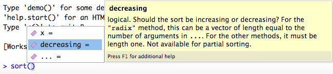

Hace unos minutos mencionamos la función list.dirs(), sin embargo no la utilizamos. La razón de ello es que por default tiene el argumento recursive=TRUE. El argumento recursive=TRUE enlista todos los directorios que se encuentran en el directorio actual y luego enlista todos los directorios presentes en éstos directorios y así sucesivamente.

```r
list.dirs("/", recursive = FALSE)
```

```
##  [1] "//.dbfseventsd"
##  [2] "//.DocumentRevisions-V100"
##  [3] "//.fseventsd"
##  [4] "//.PKInstallSandboxManager-SystemSoftware"
##  [5] "//.Spotlight-V100"
##  [6] "//.vol"
##  [7] "//Applications"
##  [8] "//bin"
##  [9] "//cores"
## [10] "//dev"
## [11] "//etc"
## [12] "//home"
## [13] "//Library"
## [14] "//net"
## [15] "//Network"
## [16] "//opt"
## [17] "//private"
## [18] "//sbin"
## [19] "//System"
## [20] "//tmp"
## [21] "//Users"
## [22] "//usr"
## [23] "//var"
## [24] "//Volumes"
```

##### Matrices en R

Las matrices en R están diseñadas para contener un solo tipo de dato (numérico, texto o lógico)

```r
m <- matrix(data = 1:10, nrow = 5, ncol=2)
m
```

```
##      [,1] [,2]
## [1,]    1    6
## [2,]    2    7
## [3,]    3    8
## [4,]    4    9
## [5,]    5   10
```

Accediendo a las filas

```r
m[1,]
```

```
## [1] 1 6
```

Accediendo a las columnas

```r
m[,2]
```

```
## [1]  6  7  8  9 10
```

Accesando alguna celda específica

```r
m[3,2]
```

```
## [1] 8
```

##### Agregando filas y columnas a una matriz

Agregando filas

```r
rbind(m, c(21, 4))
```

```
##      [,1] [,2]
## [1,]    1    6
## [2,]    2    7
## [3,]    3    8
## [4,]    4    9
## [5,]    5   10
## [6,]   21    4
```

Agregando columnas

```r
cbind(m, 20:16)
```

```
##      [,1] [,2] [,3]
## [1,]    1    6   20
## [2,]    2    7   19
## [3,]    3    8   18
## [4,]    4    9   17
## [5,]    5   10   16
```

**IMPORTANTE**: el número de elementos debe coincidir para evitar un error en R

##### Nombres para filas y columnas

Nombres para filas con rownames()

```r
rownames(m) <- paste("gen", 1:5, sep = "_")
```

La función paste() se usa para concatenar texto, uno o más elementos, con un separador dado. En este caso tenemos dos elementos, el primero de ellos es “gen”, el segundo de ellos es un vector numérico que va de 1 a 5 y finalmente nuestro separador es "_".

```r
colnames(m) <- c("condicion_A", "condicion_B")
```

Veamos el resultado de asignar nombres de filas y de columnas:

```r
m
```

```
##       condicion_A condicion_B
## gen_1           1           6
## gen_2           2           7
## gen_3           3           8
## gen_4           4           9
## gen_5           5          10
```

**IMPORTANTE**: el número de elementos debe coincidir

##### Operaciones con matrices

Sumar las filas

```r
rowSums(m)
```

```
## gen_1 gen_2 gen_3 gen_4 gen_5
##     7     9    11    13    15
```

Sumar las columnas

```r
colSums(m)
```

```
## condicion_A condicion_B
##          15          40
```

Obtener la media de las filas con rowMeans (y colMeans para columnas)

```r
rowMeans(m)
```

```
## gen_1 gen_2 gen_3 gen_4 gen_5
##   3.5   4.5   5.5   6.5   7.5
```

operaciones aritméticas a la matriz completa

```r
m/2
```

```
##       condicion_A condicion_B
## gen_1         0.5         3.0
## gen_2         1.0         3.5
## gen_3         1.5         4.0
## gen_4         2.0         4.5
## gen_5         2.5         5.0
```

Y mucho más… Funciones para álgebra lineal como: t() transposición de una matriz %*% multiplicación de matrices o de una matriz con un vector

### PRACTICA: Leyendo tablas en R e inspecionando su contenido

##### Descargando archivo de la práctica

Para poder realizar la siguiente práctica necesitas descargar el archivo ensembl_info.txt disponible en el siguiente link haciendo click:

ensembl file link

Cópialo y pégalo en un archivo de texto plano con el mismo nombre ensembl_info.txt. La mayoría de las terminales (Linux y Mac) tienen un editor de texto muy sencillo llamado **nano**. Puedes llamarlo desde la terminal con las siguientes instrucciones:

- Abrir terminal (Linux, MacOS)
- nano
- Pegar el contenido en el archivo (ctrl v)
- Guardar el archivo en nano (ctrl o)
- Poner el nombre ensembl_info.txt

Si usar Linux o Mac, puedes abrir una terminal y correr el siguiente comando: wget https://bbermudez.github.io/ensembl_info.txt

**No usar Microsoft Word**.

##### Leyendo tablas en R e inspecionando su contenido

**IMPORTANTE**: indicar en qué directorio está el archivo en tú computadora

```r
ens_tab = read.table("/Users/beto/github.bbermudez/bbermudez.github.io/ensembl_info.txt")
```

En qué formato se leen las tablas a partir de archivos?

```r
class(ens_tab)
```

```
## [1] "data.frame"
```

A diferencia de las matrices, los data frames permiten almacenar diferentes tipos de datos (numéricos, caracteres, lógicos, etc.)

dim() nos indica el número de filas y columnas (también funciona con matrices)

```r
dim(ens_tab)
```

```
## [1] 26 10
```

head muestra las primeras filas

```r
head(ens_tab)
```

```
##              coding_genes ncrna_genes pseudo_genes coding_gene_avg_length
## Anole_lizard        18595        7168          157               35332.78
## C_elegans           20362         922         1658                3088.45
## Cat                 19493        1855          542               36566.75
## Chicken             18346        6490           43               24355.34
## Chimpanzee          18759        8681          572               53191.61
## Cow                 19994        3825          797               39145.97
##              ncrna_gene_avg_length pseudo_gene_avg_length
## Anole_lizard              10318.72                 878.24
## C_elegans                   334.04                1389.75
## Cat                         103.16                 792.30
## Chicken                   12638.01                1012.88
## Chimpanzee                  125.81                 901.91
## Cow                         111.60                 859.42
##              coding_trans_avg_length ncrna_trans_avg_length
## Anole_lizard                 2572.26                 548.16
## C_elegans                    1399.78                 255.94
## Cat                          2169.50                 103.16
## Chicken                      2073.08                 859.23
## Chimpanzee                   2541.03                 125.81
## Cow                          2046.76                 111.60
##              pseudo_trans_avg_length genome_length
## Anole_lizard                  868.57    1799143587
## C_elegans                     855.84     100286401
## Cat                           743.36    2455541136
## Chicken                       993.67    1230258557
## Chimpanzee                    883.45    3309577922
## Cow                           815.04    2670422299
```

NOTA: En este caso hemos usado read.table() con un sólo argumento, el archivo a leer. En realidad read.table() tiene una gran cantidad de argumentos posibles para poder cambiar su comportamiento. Algunos ejemplos de lo que se puede hacer es: usar separadores de columnas específicos (tabulador, comas, etc.), especificar si el archivo tiene encabezado o no, establecer alguna columna como nombre de las filas, etc.

Para mayor información puedes consultar ?read.table() o realizar búsquedas en Google si te llegas a topar con algún problema leyendo tablas.

##### Accesando a los datos de Humano (filas)

```r
ens_tab["Human",]
```

```
##       coding_genes ncrna_genes pseudo_genes coding_gene_avg_length
## Human        22097       15502        16146               62651.06
##       ncrna_gene_avg_length pseudo_gene_avg_length coding_trans_avg_length
## Human              14626.52                3763.29                 3506.79
##       ncrna_trans_avg_length pseudo_trans_avg_length genome_length
## Human                 647.39                  814.55    3096649726
```

```r
ens_tab[15,]
```

```
##       coding_genes ncrna_genes pseudo_genes coding_gene_avg_length
## Human        22097       15502        16146               62651.06
##       ncrna_gene_avg_length pseudo_gene_avg_length coding_trans_avg_length
## Human              14626.52                3763.29                 3506.79
##       ncrna_trans_avg_length pseudo_trans_avg_length genome_length
## Human                 647.39                  814.55    3096649726
```

Buena práctica: Utiliza nombres de filas/columnas en vez de posiciones numéricas, ya que étas pueden cambiar

##### Accesando al tamaõ de genoma (columnas)

Existen varias maneras de accesar a las columnas de un data.frame, la primera de ellas es usar corchetes con una comma, seguido del nombre de la columna de interés

```r
ens_tab[,"genome_length"]
```

```
##  [1] 1799143587  100286401 2455541136 1230258557 3309577922 2670422299
##  [7] 2410976875 2521923936 1105035747 3196760833  143725995  393312790
## [13] 3040677044 2474929062 3096649726 2034575300 2730871774 2299509015
## [19] 2808525991 2073148626 2870184193   12157105  461533448 3174709637
## [25] 1511735326 1371719383
```

Una forma alternativa para acceder a las columnas de un data.frame es mediante el símbolo $ y posteriormente especificar el nombre de la columna

```r
ens_tab$genome_length
```

```
##  [1] 1799143587  100286401 2455541136 1230258557 3309577922 2670422299
##  [7] 2410976875 2521923936 1105035747 3196760833  143725995  393312790
## [13] 3040677044 2474929062 3096649726 2034575300 2730871774 2299509015
## [19] 2808525991 2073148626 2870184193   12157105  461533448 3174709637
## [25] 1511735326 1371719383
```

##### El tamaño del genoma humano

Para acceder a una celda en particular hay que especificar el nombre de la fila y de la columna de interés, data.frame[“fila”,“columna”]

```r
ens_tab["Human", "genome_length"]
```

```
## [1] 3096649726
```

Una alternativa sería

```r
ens_tab["Human",]$genome_length
```

```
## [1] 3096649726
```

NOTA: Tanto los valores de filas como de columnas de data.frame[“fila”,“columna”], pueden aceptar vectores con más de un valor de interés.

Volviendo a lo nuestro, ahora sabemos que el genoma humano mide 3,096 megabases.

Pero, será el genoma más grande de la tabla?

##### Ordenando una tabla de acuerdo a los valores de una columna

**IMPORTANTE**: La función order nos regresa los índices necesarios para poder ordenar la tabla de acuerdo a una de las columnas.

En este caso, nos interesa ordenar la tabla de acuerdo al tamaño de genoma (columna genome_length) y queremos que dicho orden sea de mayor a menor, por eso usamos el argumento decreasing=TRUE

```r
idx <- order(ens_tab$genome_length, decreasing = T)
idx
```

```
##  [1]  5 10 24 15 13 21 19 17  6  8 14  3  7 18 20 16  1 25 26  4  9 23 12 11  2
## [26] 22
```

Tomemos un momento para digerir la salida de order(). Tenemos una serie de valores numéricos enteros, éstos representan el orden que deberían tomar los elementos de ens_tab$genome_length para estar ordenados de mayor a menor.

A continuación vamos a usar este vector en la zona de “fila” del data.frame, de ésta manera los elementos del data.frame resultan ordenados de acuerdo a genome_length.

Dado que la tabla tiene 10 columnas, sólo vamos a imprimir algunas de interés aprovechando un vector.

```r
ens_tab[idx, c("genome_length", "coding_genes", "ncrna_genes")]
```

```
##                 genome_length coding_genes ncrna_genes
## Chimpanzee         3309577922        18759        8681
## Elephant           3196760833        20033        2644
## Tasmanian_devil    3174709637        18788        1490
## Human              3096649726        22097       15502
## Gorilla            3040677044        20962        6701
## Rat                2870184193        22258        8715
## Pig                2808525991        21605        3024
## Mouse              2730871774        22176       10467
## Cow                2670422299        19994        3825
## Dolphin            2521923936        16550        3790
## Horse              2474929062        20449        2142
## Cat                2455541136        19493        1855
## Dog                2410976875        19856       11898
## Panda              2299509015        19343        3141
## Platypus           2073148626        21698        7531
## Microbat           2034575300        19728        4408
## Anole_lizard       1799143587        18595        7168
## Xenopus            1511735326        18442        1306
## Zebrafish          1371719383        25658        4182
## Chicken            1230258557        18346        6490
## Duck               1105035747        15634         567
## Stickleback         461533448        20787        1617
## Fugu                393312790        18523         703
## Fruitfly            143725995        13918        2832
## C_elegans           100286401        20362         922
## S_cerevisiae         12157105         6692          99
```

Podemos ver que tanto los chimpancés como los elefantes y hasta los demonios de Tasmania tienen un genoma más grande que el nuestro. Pfffff!!! que duro golpe al ego antropocentrista :V

##### Graficas en R base: tamaño de genoma

Comparar valores en una tabla está bien, pero a veces no es lo más cómodo para tener una visión general de los valores. Algunos de nosotros somos más visuales y preferimos observar los datos en una figura.

Podemos tener una representación visual de los tamaños de genoma con una gráfica de barras con la función barplot() el primer argumento de ésta función es un vector o una matriz que indique el tamaño de las barras.

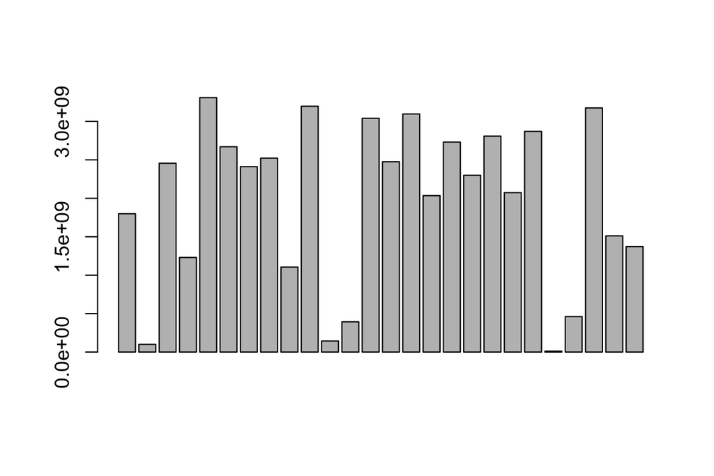

```r
barplot(height = ens_tab$genome_length)
```

**Felicidades!!!** acabas de hacer tú primera figura en R.

Ok, pero no es exactamente una gráfica que mi madre pondría en el refrigerador con orgullo.

Ahora tenemos nuestra imagen, pero las barras no tienen nombres!.

Esto se soluciona usando el argumento names.arg= e indicando los nombres de las filas del data.frame

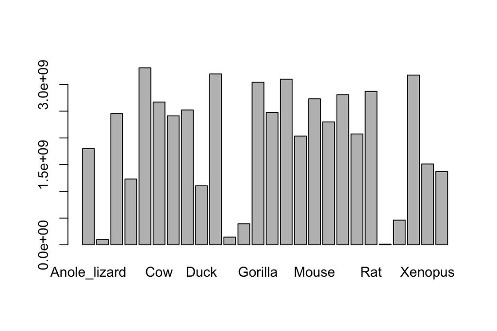

```r
barplot(height = ens_tab$genome_length, names.arg = rownames(ens_tab))
```

Ya tenemos nombres, por lo menos para algunas de las barras. Podemos cambiar la orientación de los nombres con el argumento las=2

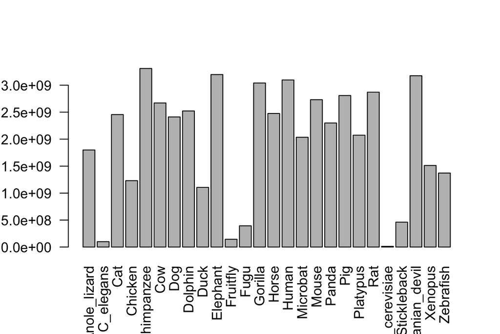

```r
barplot(height = ens_tab$genome_length, names.arg = rownames(ens_tab), las=2)
```

##### Graficando en R base : genes codificantes

Parte muy importante de la bioinformática consiste en la exploración visual de los datos. La visualización de los datos puede sugerir relaciones entre variables. Veamos el número de genes codificantes de la tabla de ensembl.

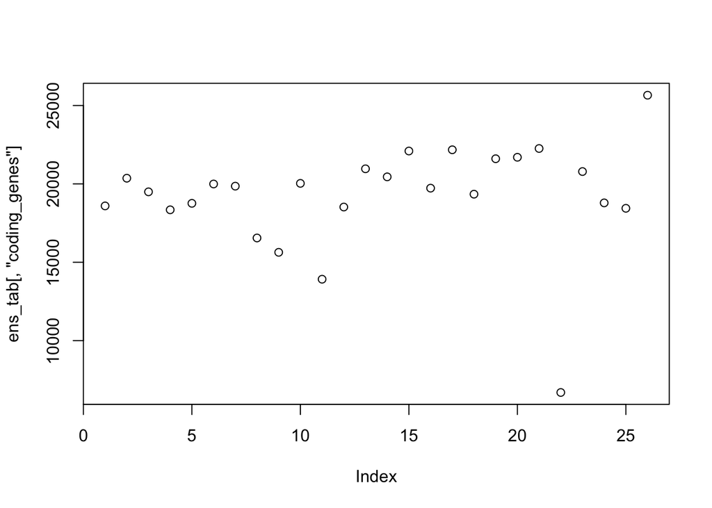

```r
plot(ens_tab[,"coding_genes"])
```

Una imagen similar a ésta debe aparecer en la zona de figuras

El eje Y representa el número de genes codificantes a proteínas, el eje X simplemente representa la posición de cada genoma en la tabla

##### Graficando en R: relacionando variables

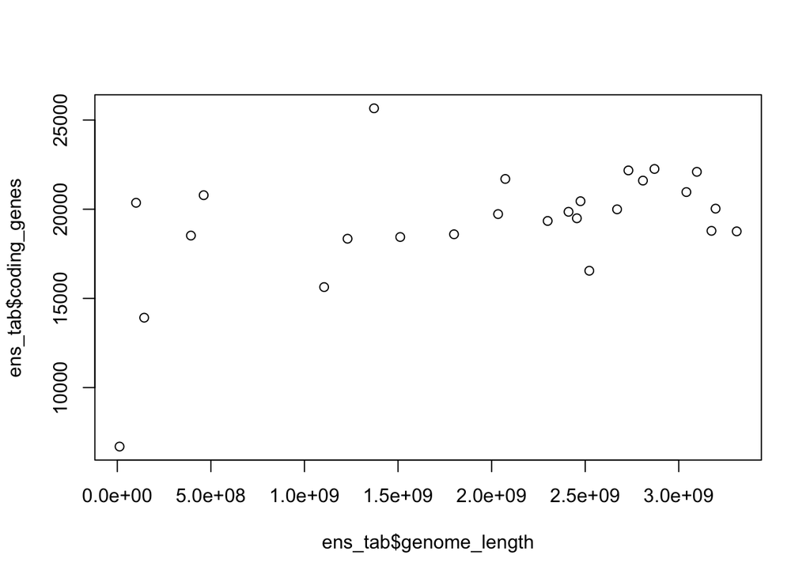

```r
plot(ens_tab$genome_length, ens_tab$coding_genes)
```

Ahora tenemos una representación visual de la relación entre el número de genes codificantes (eje Y) y el tamaño de genoma (eje X).

Sin embargo, no podemos saber qué punto corresponde a qué organismo.

##### Agregando texto a gráficas para facilitar su interpretación

La función text nos ayuda a agregar texto a gráficas de acuerdo a coordenadas X y Y

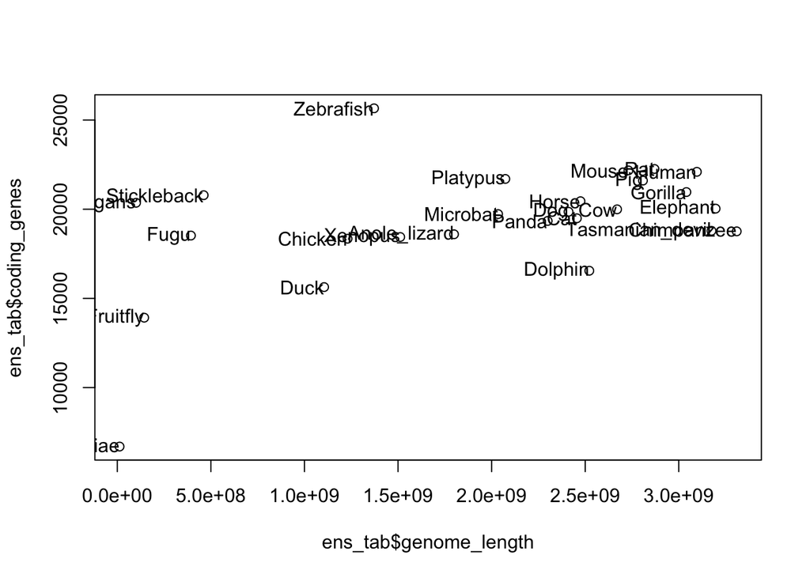

```r
plot(ens_tab$genome_length, ens_tab$coding_genes)
text(ens_tab$genome_length, ens_tab$coding_genes, labels = rownames(ens_tab), adj = 1)
```

El argumento labels representa el texto que queremos añadir, podemos usar los nombres de los organismos de la tabla es decir rownames(ens_tab).

El argumento adj=1 hace un ajuste al texto para que no quede exactamente sobre el punto que se graficó.

Vaya sorpresa! un simple pez zebra tiene 3561 más genes que nostros.

##### diagrama de dispersión scatter.smooth()

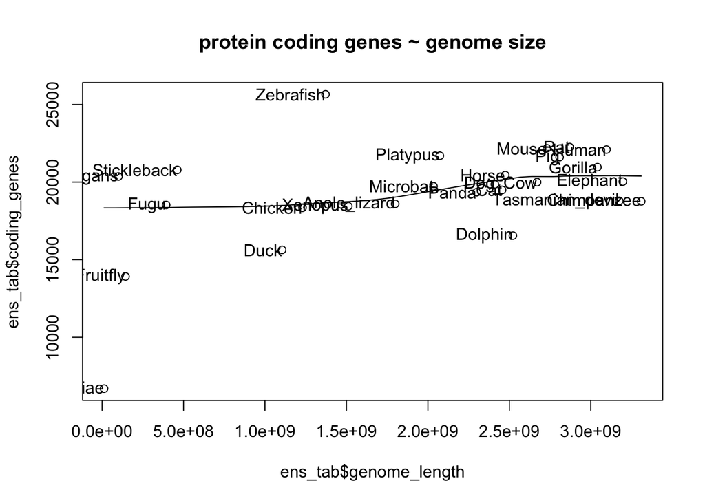

```r
scatter.smooth(x = ens_tab$genome_length, y = ens_tab$coding_genes, main="protein coding genes ~ genome size")
text(ens_tab$genome_length, ens_tab$coding_genes, labels = rownames(ens_tab), adj = 1)
```

Adicionalmente, parece que un gran tamaño de genoma no necesariamente implica un gran número de genes codificantes para proteínas. Sigamos explorando, quizás logremos ganar en algo.

##### Relacionando variables

Exploremos ahora los genes de RNAs no codificantes.

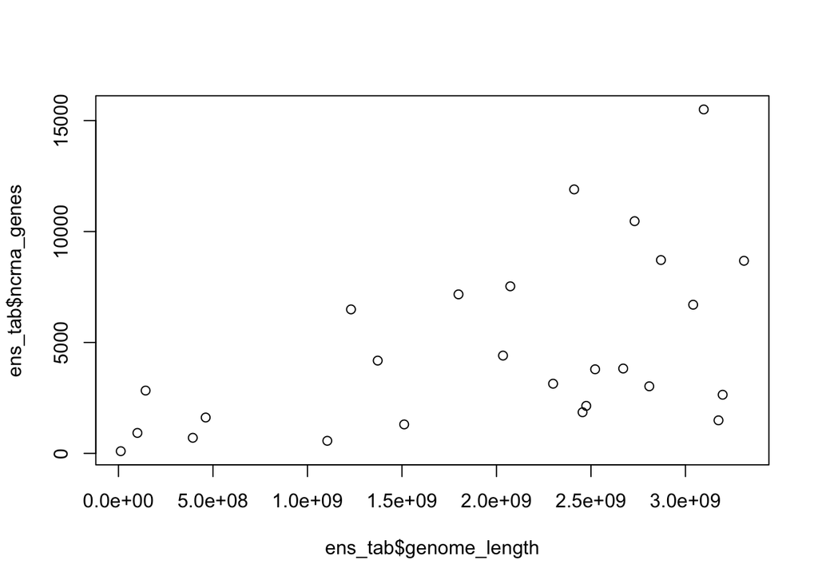

```r
plot(ens_tab$genome_length, ens_tab$ncrna_genes)
```

Ahora tenemos una representación visual de la relación entre el número de genes no codificantes (eje Y) y el tamaño de genoma (eje X).

Más adelante compararemos las gráficas.

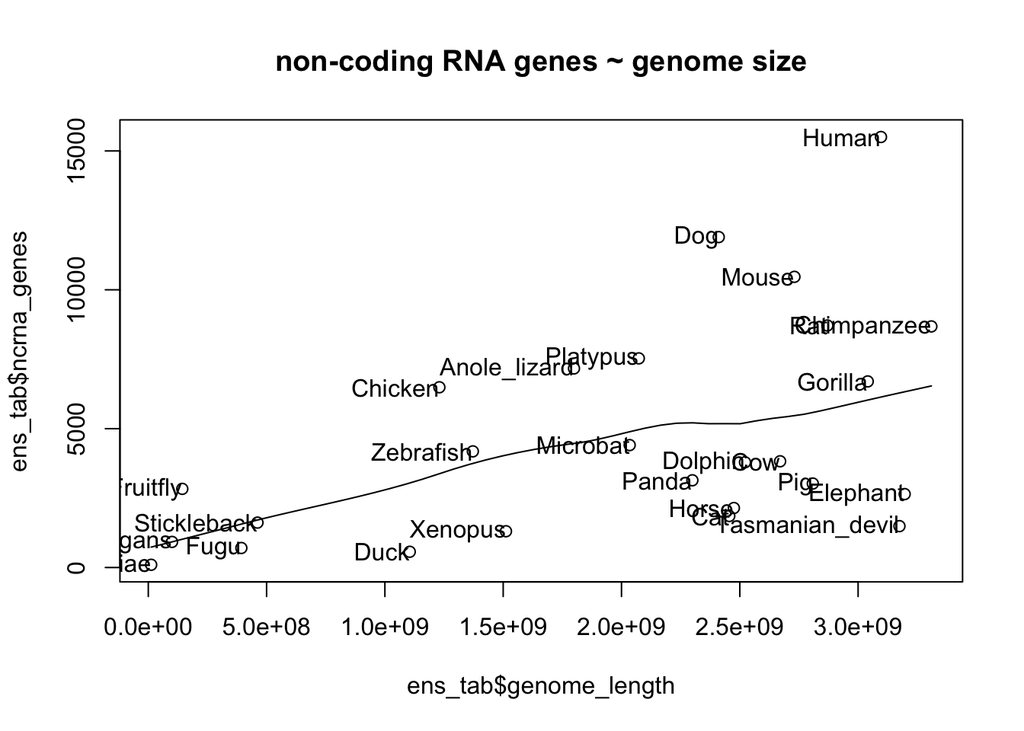

```r
scatter.smooth(x = ens_tab$genome_length, y = ens_tab$ncrna_genes, main="non-coding RNA genes ~ genome size")
text(ens_tab$genome_length, ens_tab$ncrna_genes, labels = rownames(ens_tab), adj = 1)
```

##### Genoma codificante vs genoma no codificante

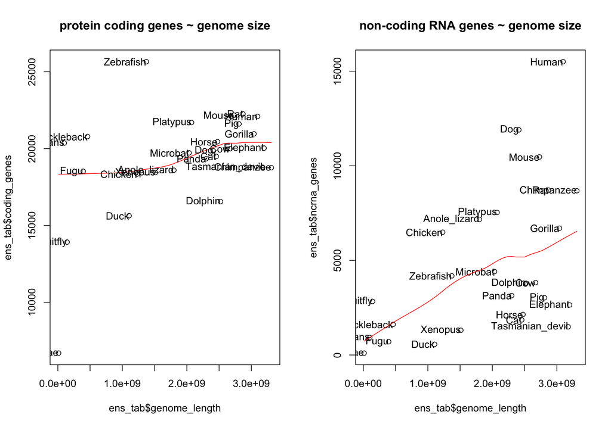

```r
par(mfrow=c(1,2))
plot(ens_tab$genome_length, ens_tab$coding_genes, main="protein coding genes ~ genome size")
with(ens_tab, lines(loess.smooth(genome_length, coding_genes), col = "red"))
text(ens_tab$genome_length, ens_tab$coding_genes, labels = rownames(ens_tab), adj = 1)
plot(ens_tab$genome_length, ens_tab$ncrna_genes, main="non-coding RNA genes ~ genome size")
text(ens_tab$genome_length, ens_tab$ncrna_genes, labels = rownames(ens_tab), adj = 1)
with(ens_tab, lines(loess.smooth(genome_length, ncrna_genes), col = "red"))
```

Podemos mezclar gráficos en R de distintas maneras, una de ellas es con un argumento de la función par(), la función par() sirve para definir una gran cantidad de parámetros para graficar.

##### Probando correlación entre variables con la función cor()

Probando la correlación entre la longitud del genoma y el número de genes codificantes para proteínas con la función cor()

```r
cor(ens_tab$genome_length, ens_tab$coding_genes)
```

```
## [1] 0.4756171
```

Probando la correlación entre el tamaño de genoma y el número de genes de RNAs no codificantes

```r
cor(ens_tab$genome_length, ens_tab$ncrna_genes)
```

```
## [1] 0.5104786
```

Cómo interpretarías estos resultados?

### PRACTICA: Lectura y descripción de secuencias fasta dentro de R

#### Objetivo

Hacer descripciones básicas de un par de archivos de secuencias fasta

##### *Burkholderia cenocepacia* y *Glomeribacter gigasporarum*

*Burkholderia cenocepacia* Es una bacteria patógena oportunista cuyas infecciones son comunes en pacientes con fibrosis quística. Es una bacteria de vida libre cultivable.

*Glomeribacter gigasporarum* Es una bacteria endosimbionte intracelular obligada de mycorhizas arbusculares de la especie *Gigaspora margarita*. Es una bacteria no cultivable que ha perdido la capacidad de vivir fuera de su hospedero.

Ambas especies son betaproteobacterias pertenecientes a la familia Burkholderiaceae

##### Instalando paquetes de R

Existen varias maneras de instalar paquetes de R: 1. Entrar a R en una terminal y correr las siguientes líneas: if (!requireNamespace(“BiocManager”, quietly = TRUE)) install.packages(“BiocManager”) BiocManager::install(“Rsamtools”)

2. Entrar a R y correr: source(“https://bioconductor.org/biocLite.R”) BiocInstaller::biocLite(“Rsamtools”)
3. Desde RStudio hacer click en Packages en la ventana inferior derecha, Posteriormente elegir Install Después ingresar el nombre del paquete de interés

##### Descargando los archivos de la práctica

Haz click en el siguiente link:

https://bbermudez.github.io/bact_genomes.zip

Elige descargar y descomprime el archivo en tu directorio de trabajo, si estás en Windows puedes hacer click secundario en el archivo y elegir extraer.

Si estás en Linux o MacOS puedes correr los siguientes comandos en la terminal

wget https://bbermudez.github.io/bact_genomes.zip

unzip bact_genomes.zip

NOTA: Recuerda tomar nota de dónde guardaste tus archivos para poder indicar a R su localización.

Una vez que tengas los 3 archivos .cds.fasta.gz en tu directorio de trabajo estás list@ para seguir con la práctica

```
## [1] "Burkholderia_cenocepacia.cds.fasta.gz"
## [2] "Burkholderia_rhizoxinica.cds.fasta.gz"
## [3] "ensembl_info.txt"
## [4] "Glomeribacter_gigasporarum.cds.fasta.gz"
```

##### Práctica: Leyendo secuencias fasta dentro de R

La función scanFa, que forma parte del paquete Rsamtools, ayuda a leer archivos fasta o sus índices (información de nombres de secuencias y longitudes).

Para poder usar la función scanFa, tenemos que haber instalado el paquete Rsamtools previamente y cargarlo en nuestra sesión actual de R mediante la función library()

```r
library(Rsamtools)
```

TIP: Cuando hago un script de R, suelo cargar los paquetes necesarios en las líneas iniciales del script, adicionalmente me gusta poner un breve comentario sobre por qué usamos dicho paquete en el script actual. A continuación pongo dos ejemplos:

```r
library(Rsamtools) # scanFa()
library(Rsamtools) # we will import DNA fasta files in this script
```

Ahora sí, vamos a usar la función scanFa() para poder generar un objeto en R que tenga todos los genes de *Burkholderia cenocepacia*.

Recuerda reemplazar el directorio que aquí se muestra por tu directorio de trabajo.

```r
bce_fa <- scanFa(file = "/Users/beto/Dropbox/JRB/Slides/Teaching/intro_R_data/Burkholderia_cenocepacia.cds.fasta.gz")
bce_fa
```

```
##   A DNAStringSet instance of length 7788
##        width seq                                            names
##    [1]  1317 ATGCCGCGCAAGCCCGCAAGCA...AGCAGCCTCGCAGGCAACTGA gi|191639869|ref|...
##    [2]  1032 ATGGCTAAGGACACCTCGAAAG...GCGACGGCCACGTCAAAGTAA gi|191639869|ref|...
##    [3]   696 ATGGCTTTCAAGATCGCCGTCA...ACCGGAGCCGCCCATGGCTAA gi|191639869|ref|...
##    [4]  1047 GTGCTGGTCTTCCTGAAGCCCG...GATTCACTTCATCGGGCTTGA gi|191639869|ref|...
##    [5]   786 ATGGTCGAGCCGAGCTTCGGCC...TCGATCGTGGCGAGCTATTGA gi|191639869|ref|...
##    ...   ... ...
## [7784]    73 GGGGGCATAGCTCAGCTGGGAG...GTTCGATCCCGTCTGCCTCCA gi|206561868|ref|...
## [7785]    74 GGGTCTGTAGCTCAGTCGGTTA...GTTCGAATCCAACCAGACCCA gi|206561868|ref|...
## [7786]    74 GGGTCTGTAGCTCAGTCGGTTA...GTTCGAATCCAACCAGACCCA gi|206561868|ref|...
## [7787]  1590 CTTACACATGCAAGTCGAACGG...TAGAGCACCGTCTTGATAAGG gi|206561868|ref|...
## [7788]  1590 CTTACACATGCAAGTCGAACGG...TAGAGCACCGTCTTGATAAGG gi|206561868|ref|...
```

Podemos ver que bce_fa se trata de un objeto del tipo DNAStringSet. Al imprimr un objecto DNAStringSet obtenemos una impresión que nos muestra ejemplos del contenido del objeto en sus primeros y últimos elementos. Tenemos información de la longitud de los genes codificantes de *B. cenocepacia*, tenemos la secuencia de dichos genes y los primeros caracteres de sus nombres (encabezados fasta).

##### Accesando a los elementos de un objeto DNAStringSet

Podemos acceder a los distintos elementos de información de un objeto DNAStringSet con las funciones names() y width()

Ahora bien, frecuentemente en Bioinformática/Genómica vamos a manejar datos grandes de Mb o Gb, en este caso bce_fa tiene 7788 secuencias por ello vamos a usar la función head() para ver sólo los primeros elementos de la salida de names() y width().

Accediendo a los nombres de las secuencias (fasta headers)

```r
head(names(bce_fa))
```

```
## [1] "gi|191639869|ref|NC_011002.1|:0-1317(+)"
## [2] "gi|191639869|ref|NC_011002.1|:1412-2444(-)"
## [3] "gi|191639869|ref|NC_011002.1|:2436-3132(-)"
## [4] "gi|191639869|ref|NC_011002.1|:4782-5829(-)"
## [5] "gi|191639869|ref|NC_011002.1|:6085-6871(-)"
## [6] "gi|191639869|ref|NC_011002.1|:7233-8358(-)"
```

Así como hay una función head(), existe una función tail() para ver los últimos elementos de un objeto.

Accediendo a la información de la longitud de los genes codificantes de *B. cenocepacia*

```r
tail(width(bce_fa))
```

```
## [1]   73   73   74   74 1590 1590
```

Si quieres, puedes echar un vistazo a la salida completa de with(bce_fa) o names(bce_fa). Notarás que posiblemente se llene la pantalla de números o de nombres de secuencias y que incluso se “sature” la capacidad de impresión de un objeto, obteniendo un mensaje parecido a:

[ reached getOption(“max.print”) – omitted 3357 entries ]

##### Analizando las longitudes de genes de *B. cenocepacia*: medidas de tendencia central

Promedio de las longitudes

```r
mean(width(bce_fa))
```

```
## [1] 903.5745
```

Mediana de las longitudes

```r
median(width(bce_fa))
```

```
## [1] 825
```

```r
sd(width(bce_fa))
```

```
## [1] 689.7263
```

##### Los genes más pequeños de *B. cenocepacia*: Usando índices lógicos para encontrar información

IMPORTANTE: Ahora vamos a aprender a hacer un subconjunto de nuestro objeto orignal con aquellos elementos que cumplen con un criterio de nuestro interés.

Ésta es una tarea de rutina, en la manipulación de datos dentro de R, te recomiendo dedicar unos minutos a tratar de entender lo que está pasando, yo haré mi mejor esfuerzo para tratar de explicarlo lo más claro posible

En este caso vamos a usar un índice lógico (TRUE/FALSE) para poder acceder a las secuencias que son más cortas que 100 nucleótidos.

```r
idx_short <- width(bce_fa) < 100
```

Vamos a echarle un vistazo al objeto que acabamos de generar, pero nuevamente usaremos la función head() para poder ver los primeros elementos de dicho objeto, ya que almacena una gran cantidad de elementos

```r
head(idx_short)
```

```
## [1] FALSE FALSE FALSE FALSE FALSE FALSE
```

```r
table(idx_short)
```

```
## idx_short
## FALSE  TRUE
##  7642   146
```

NOTA: Como podrás ver, aplicamos la función table al objeto idx_short completo y no a head(idx_short), si aplicáramos hiciéramos table(head(idx_short)) sólo obtendríamos el resultado para los primeros elementos

Ahora usaremos este índice lógico para extraer las secuencias más cortas que 100 nt

```r
bce_fa[idx_short]
```

```
##   A DNAStringSet instance of length 146
##       width seq                                             names
##   [1]    73 GGGGGCATAGCTCAGCTGGGAG...GGTTCGATCCCGTCTGCCTCCA gi|191639869|ref|...
##   [2]    73 GGGGGCATAGCTCAGCTGGGAG...GGTTCGATCCCGTCTGCCTCCA gi|191639869|ref|...
##   [3]    74 GGGTCTGTAGCTCAGTCGGTTA...GGTTCGAATCCAACCAGACCCA gi|191639869|ref|...
##   [4]    74 GGGTCTGTAGCTCAGTCGGTTA...GGTTCGAATCCAACCAGACCCA gi|191639869|ref|...
##   [5]    73 GCGCCCGTAGCTCAATGGATAG...GGTTCGATCCCAGCCGGGCGCG gi|206558403|ref|...
##   ...   ... ...
## [142]    82 GCCGACGTGGTGAAATTGGTAG...AGTTCGAGTCTCGCCGTCGGCA gi|206561868|ref|...
## [143]    73 GGGGGCATAGCTCAGCTGGGAG...GGTTCGATCCCGTCTGCCTCCA gi|206561868|ref|...
## [144]    73 GGGGGCATAGCTCAGCTGGGAG...GGTTCGATCCCGTCTGCCTCCA gi|206561868|ref|...
## [145]    74 GGGTCTGTAGCTCAGTCGGTTA...GGTTCGAATCCAACCAGACCCA gi|206561868|ref|...
## [146]    74 GGGTCTGTAGCTCAGTCGGTTA...GGTTCGAATCCAACCAGACCCA gi|206561868|ref|...
```

##### Graficando en R: histograma de longitudes de secuencias

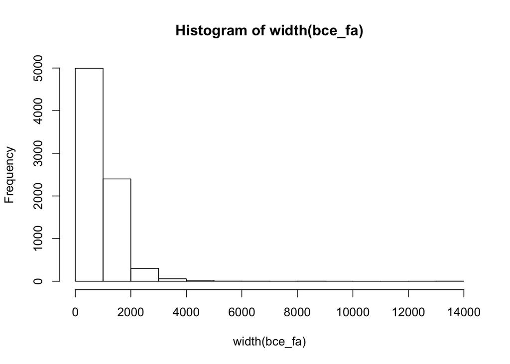

```r
hist(width(bce_fa))
```

##### Agregando color a una gráfica

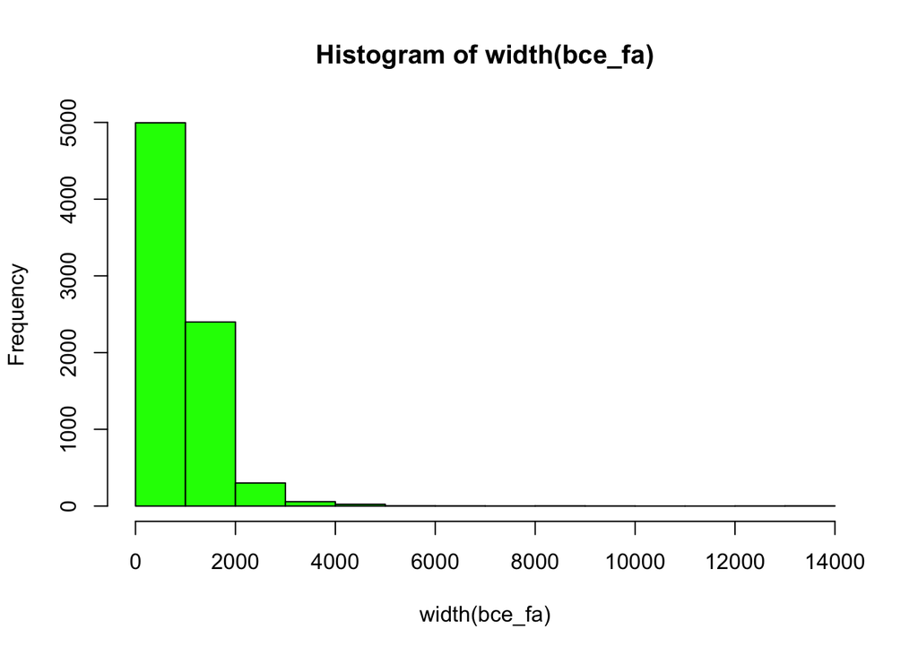

```r
hist(width(bce_fa), col="green")
```

##### Práctica: leer secuencias de Glomeribacter gigasporarum y generar un histograma de sus longitudes de secuencias (10 minutos)

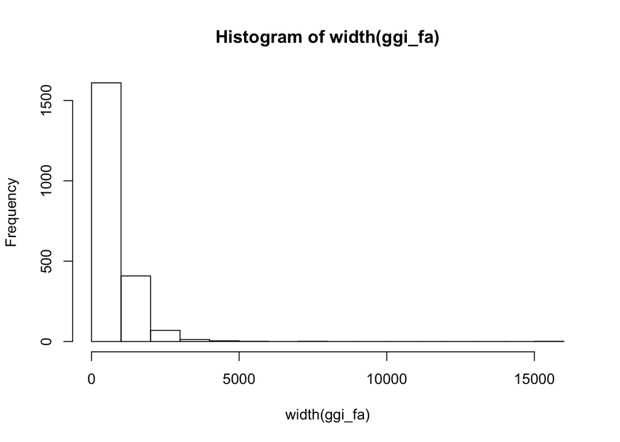

##### Mezclando gráficos

Declaramos colores con transparencia (alpha) para ambos organismos usando la función rgb(). Puedes darte cuenta en el primer caso usamos los nombres de los argumentos, mientras que para el segundo caso simplemente pasamos los valores de los argumentos que queremos usar en la función.

**WARNING**: En caso de no especificar el nombre de los argumentos explícitamente, la función espera recibir los argumentos en un orden determinado.

```r
bce_color <- rgb(red=0, green=1, blue=0, alpha = 0.5)
bap_color <- rgb(0,0,1,0.5)
```

rgb() es una función para generar colores a partir de la mezcla de colores rojo (r), verde (g) y azul (b)

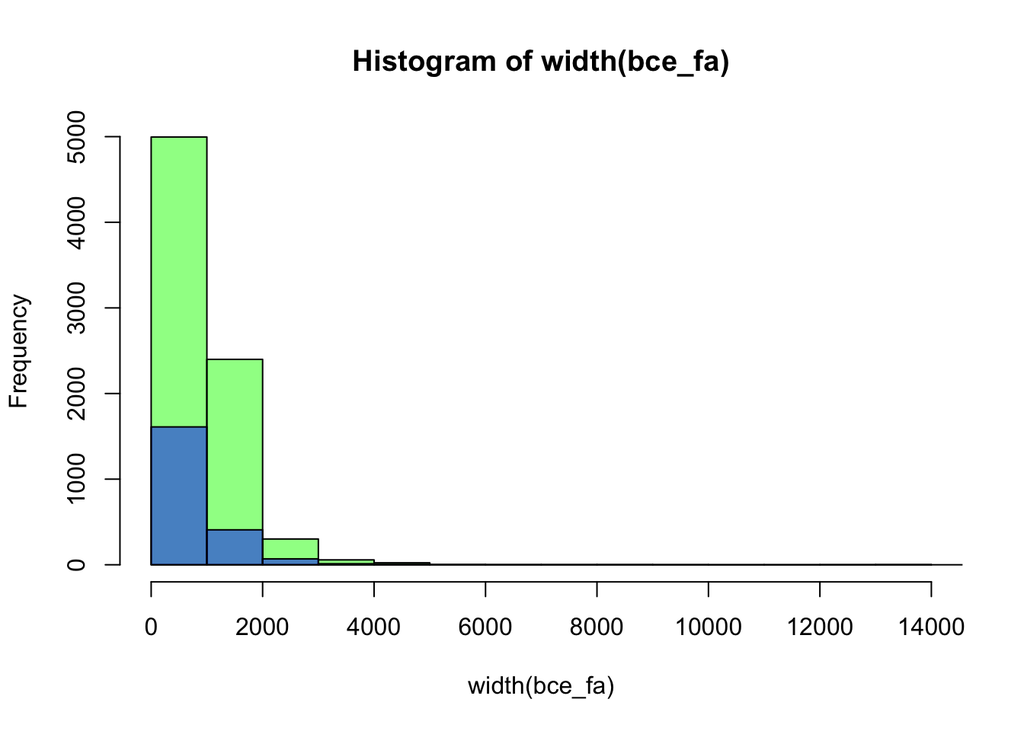

```r
hist(width(bce_fa), col = bce_color)
hist(width(ggi_fa), col = bap_color, add=TRUE)
```

El argumento add nos permite traslapar otro gráfico sobre el ya existente.

NOTA: si hubiéramos utilizado colores sólidos como “green” o “blue” no seríamos capaces de apreciar el traslape entre las gráficas.

##### El contenido de GC

Porcentaje de GC de una secuencia (gen, genoma, etc)

Contenido de GC = G + C / A + T + G + C

##### Obteniendo el contenido de GC de todos los genes

La función letterFrequency nos regresa el número de ocurrencias de ciertas letras

```r
bce_gc <- as.numeric(letterFrequency(bce_fa, letters = "CG", as.prob = TRUE))
```

El argumento as.prob = TRUE nos convierte las frecuencias a probabilidades

Por default letterFrequency nos regresa un objeto tipo matriz, para convertirlo a un vector numérico utilizamos la función as.numeric

##### Mezclando gráficos: contenido de GC

Declaramos colores con transparencia (alpha) para ambos organismos

```r
bce_color <- rgb(red = 0, green = 1,blue = 0, alpha = 0.5)
bap_color <- rgb(0,0,1,0.5)
```

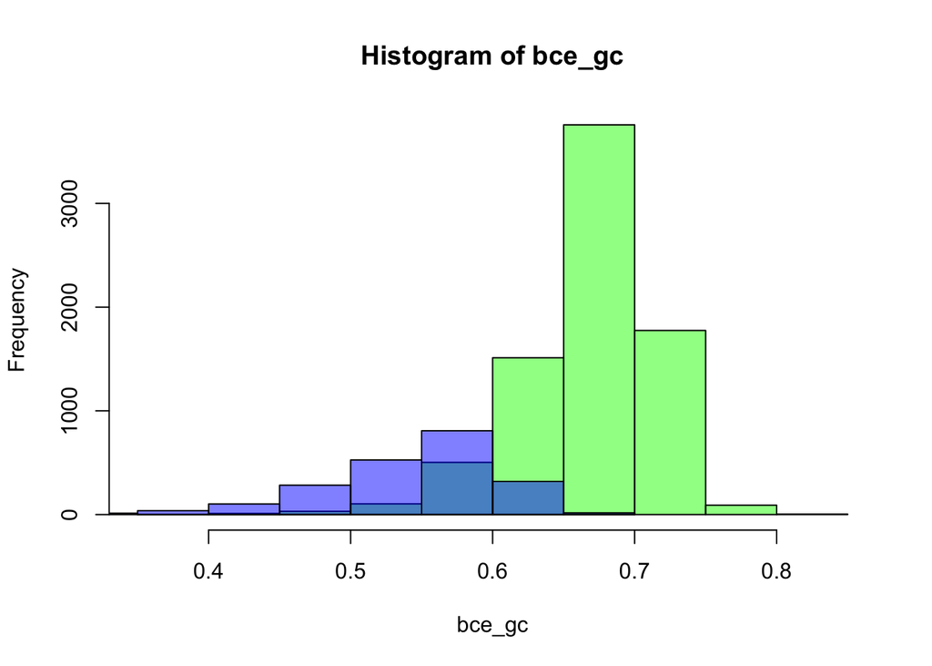

```r
hist(bce_gc, col=bce_color)
hist(bap_gc, col=bap_color, add=T)
```

##### Añadiendo título y leyenda a un gráfico

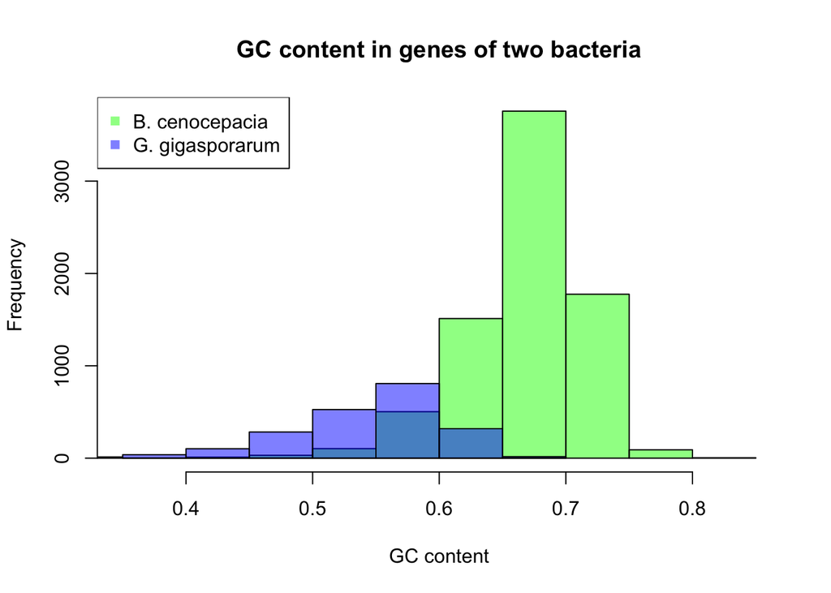

```r
hist(bce_gc, col = rgb(0,1,0,0.5), main="GC content in genes of two bacteria", xlab = "GC content")
hist(bap_gc, col=rgb(0,0,1,0.5), add=T)
legend("topleft", legend = c("B. cenocepacia", "G. gigasporarum"), col=c(bce_color, bap_color), pch = 15)
```

##### Agregando líneas a gráficos de R

abline es una función que dibuja líneas rectas, pueden tener pendiente v= línea vertical h= líneas horizonales a = punto de intersección b = pendiente de la línea

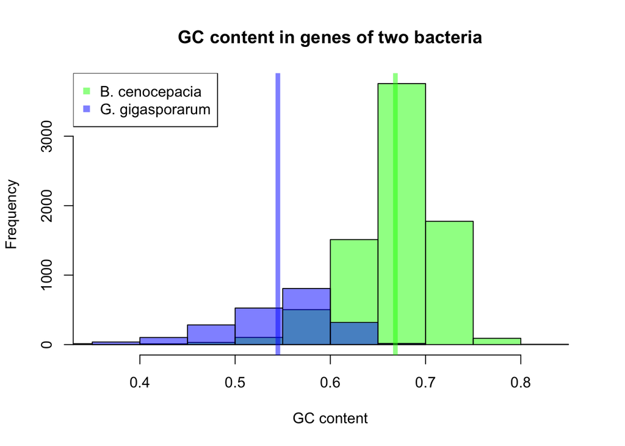

```r
hist(bce_gc, col = bce_color, main="GC content in genes of two bacteria", xlab = "GC content")
hist(bap_gc, col=bap_color, add=T)
legend("topleft", legend = c("B. cenocepacia", "G. gigasporarum"), col=c(bce_color, bap_color), pch = 15)
abline(v=mean(bce_gc), col=bce_color, lwd=5)
abline(v=mean(bap_gc), col=bap_color, lwd=5)
```

##### *Burkholderia rhizoxinica*

*Burkholderia rhizoxinica* es una betaproteobacteria que también pertenece a la familia Burkholderiaceae. *B. rhizoxinica* es una bacteria endosimbionte de hongos pertenecientes a la especie *Rhizopus microsporus*. Sin embargo, tiene la peculiaridad de que se puede cultivar en condiciones de laboratorio.

Vamos a analizar si ésta propiedad de ser un endosimbionte cultivable se refleja en el contenido de GC de *B. rhizoxinica*.

Si te interesa leer más acerca de *B. rhizoxinica* te recomiendo leer:

L. P. Partida-Martinez and C. Hertweck, “Pathogenic fungus harbours endosymbiotic bacteria for toxin production.,” Nature, vol. 437, no. 7060, pp. 884–8, Oct. 2005.

##### Incluyendo a un tercer organismo: *Burkholderia rhizoxinica*

Ahora te toca a tí, tratar de replicar una imagen como la que muestro a continuación. Para lograrlo tendrás que: - Leer el archivo de los genes de *B. rhizoxinica* - Obtener el contenido de GC - Elegir un color para el nuevo organismo - Agregar su histograma al histograma con las dos bacterias anteriores

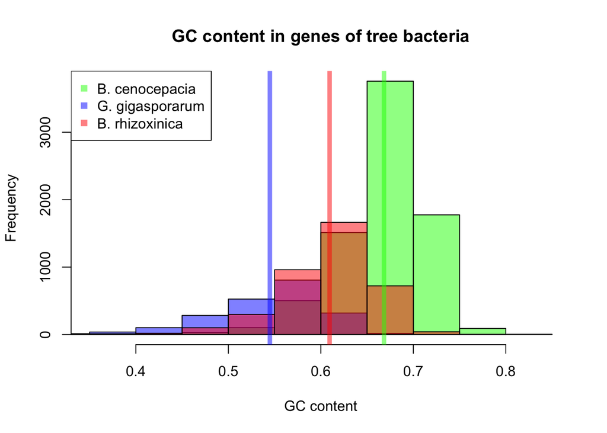

##### Reducción del contenido de GC en genomas endosimbiontes intracelulares

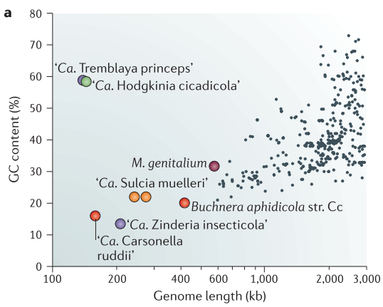

McCutcheon, J. P., & Moran, N. a. (2011). Extreme genome reduction in symbiotic bacteria. Nature Reviews Microbiology, 10(1), 13–26. http://doi.org/10.1038/nrmicro2670

##### Distintas etapas en el proceso de vida libre a endosimbiosis estricta

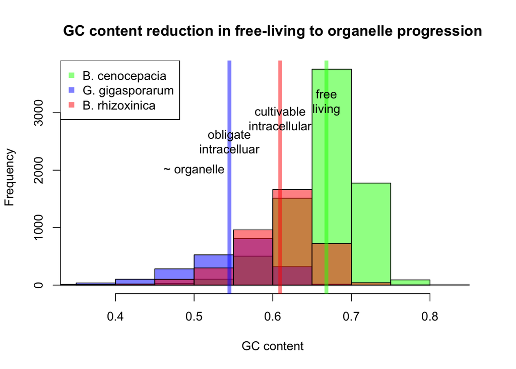

##### Las listas son otra manera de almacenar información en R

Inicializando una lista vacía

```r
l_gc <- list()
```

Agregando elementos a la lista

```r
l_gc[["B. cenocepacia"]] <- bce_gc
l_gc[["G. gigasporarum"]] <- bap_gc
```

lapply aplica la función que uno quiera (head en este caso), a una lista

```r
lapply(l_gc, head)
```

```
## $`B. cenocepacia`
## [1] 0.6097191 0.6356589 0.5704023 0.5988539 0.6234097 0.6622222
##
## $`G. gigasporarum`
## [1] 0.5770609 0.6131261 0.5212876 0.4473684 0.4651163 0.5435028
```

Las listas son muy frecuentes en R, muchos tipos de datos de algunos paquetes son simplemente listas que tienen un formato particular. Ejemplos: DGEList(edgeR), PCA

##### Los boxplots o gráficas de cajas y bigotes nos dan una idea de la distribución de los datos

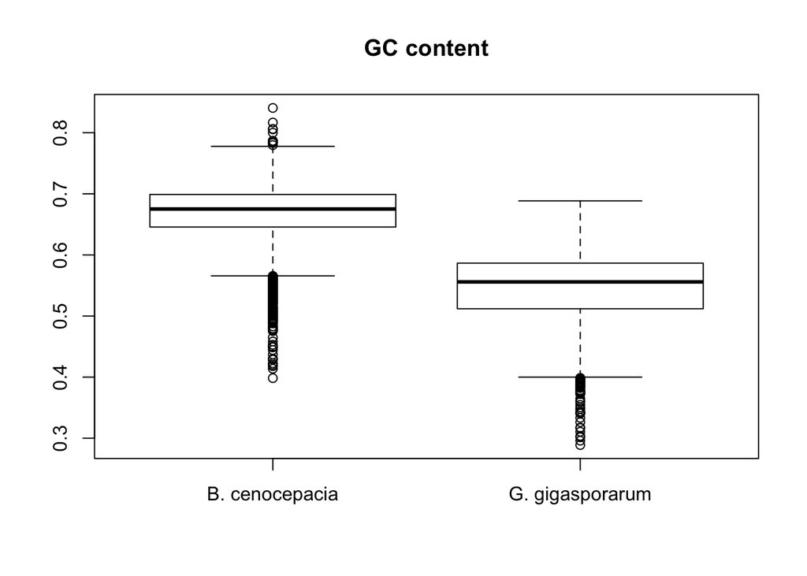

```r
boxplot(l_gc, main="GC content")
```

##### Algunas funciones disponibles que trabajan con texto

```r
DNA <- "ATGCATTAG"
```

Cuántas cadenas de texto?

```r
length(DNA)
```

```
## [1] 1
```

Cuántos caracteres?

```r
nchar(DNA)
```

```
## [1] 9
```

Extraer porciones de un texto

```r
substr(DNA, start=1, stop = 3)
```

```
## [1] "ATG"
```

Remplazar T’s por U’s en DNA

```r
sub(pattern = "T", replacement = "U", DNA)
```

```
## [1] "AUGCATTAG"
```

A diferencia de sub(), gsub reemplaza todas las ocurrencias del patrón indicado

```r
gsub(pattern = "T", replacement = "U", DNA)
```

```
## [1] "AUGCAUUAG"
```

##### Codones de inicio en *B. cenocepacia*

Vamos a aprovechar la propiedad de vectorización de R para obtener todos los codones de inicio de *B. cenocepacia*

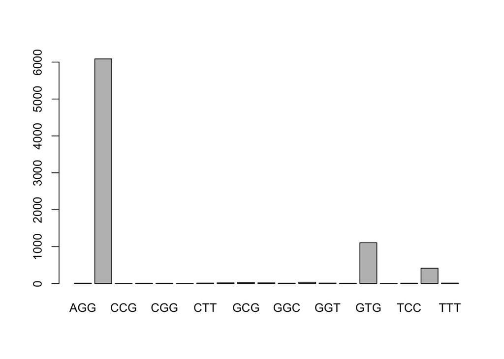

```r
tab_start <- table(substr(start = 1, stop = 3, bce_fa))
barplot(tab_start)
```

Para poder apreciar mejor los nombres de los codones podemos usar las=2, que controla la posición de las etiquetas de las barras en la función barplot()

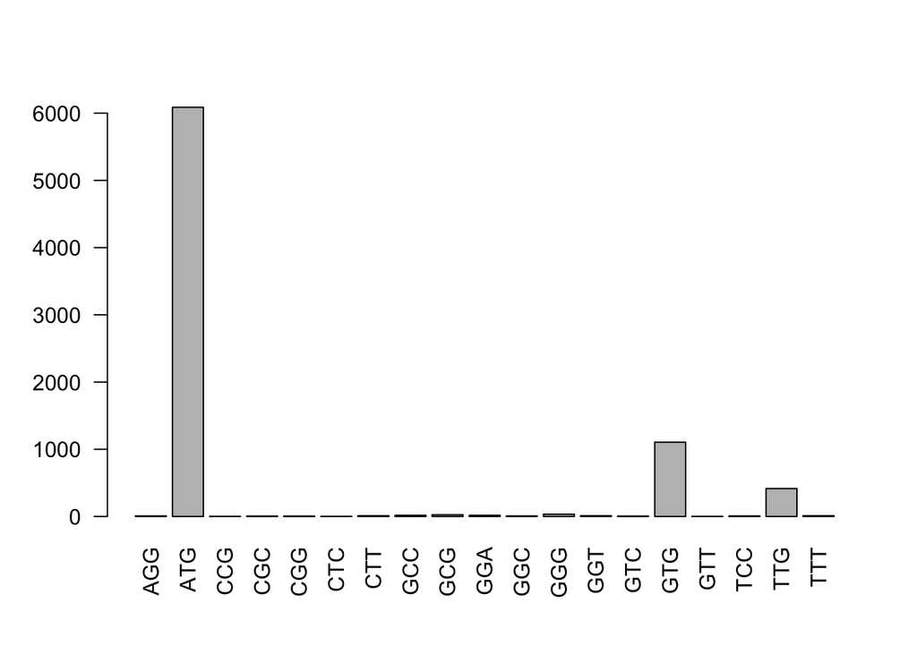

```r
barplot(tab_start, las=2)
```

##### Codones de paro en *B. cenocepacia*

```r
tab_stop <- table(substr(start=width(bce_fa)-2, stop=width(bce_fa), bce_fa))
```

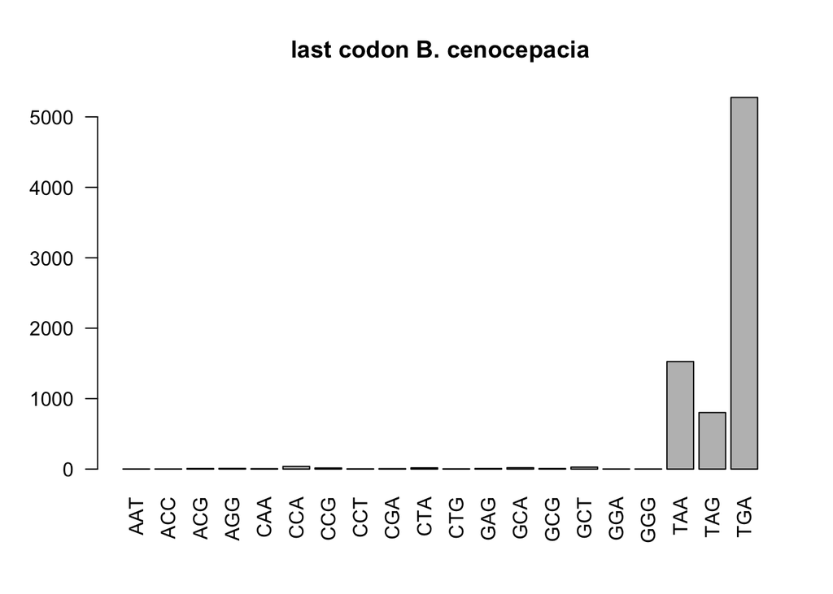

```r
barplot(tab_stop, main = "last codon B. cenocepacia", las=2)
```

##### Ejemplo de Gráfica de barras apiladas con matrices

En la siguiente matriz tenemos la información del tamaño y el primer nucleótido de una corrida de secuenciación de RNAs pequeños (sRNA-Seq). Este tipo de información se almacena convenientemente en una matriz en la que cada columna representa un tamaño de longitud de read, cada fila representa el nucleótido presente en el extremo 5’ y cada intersección de fila y columna corresponde al número de reads con tales características.

```r
m_nt
```

```
##      16    17     18     19    20     21      22     23     24    25    26
## A 46160 23723  37438  32855 48884  71962   99489  80093  43032 19752 18034
## C 45839 68326 135114 100363 78973  71782  117184  53837  29811 26501 35603
## G 53082 51691  59323  71243 41858  81455   41350  45358  33963 38772 27636
## N   152   156    256    247   211    441    1567    346    223   113    91
## U 12094 19092  14516  85942 55020 255547 1413196 212909 147488 44493 23473
##      27    28    29    30    31    32    33    34    35    36    37   38   39
## A 15574 14513 19707 15870 21090 13335 12401 28547  7147  9105 15682 5758 5486
## C 42529 27881 27837 16179 14723 21228 16552 22923 11415 48984  5799 6805 3615
## G 22283 16455 20756 30604 26644 63513 45623 26062 21022  6802  5707 7250 5149
## N    82    76    77    62    66    98    91    87    42    55    35   10   11
## U 14870 14487  7733  7166  6949  8436 13983 12443  6905  5105  2986 1993 1752
##     40    41   42   43   44  45  46  47   48   49    50
## A 2174  1403 2090  723  475 322 166 216  504 1971  4667
## C 3336  1998 1313  946 1233 503 472 384 2399 1854  3648
## G 3118 12643 1836 1177  655 344 207 185  276 1851  3799
## N    6    16    2    2    2   2   1   2    4    4     5
## U 7036   461  343  259  199 202 548 368 1252 5644 15368
```

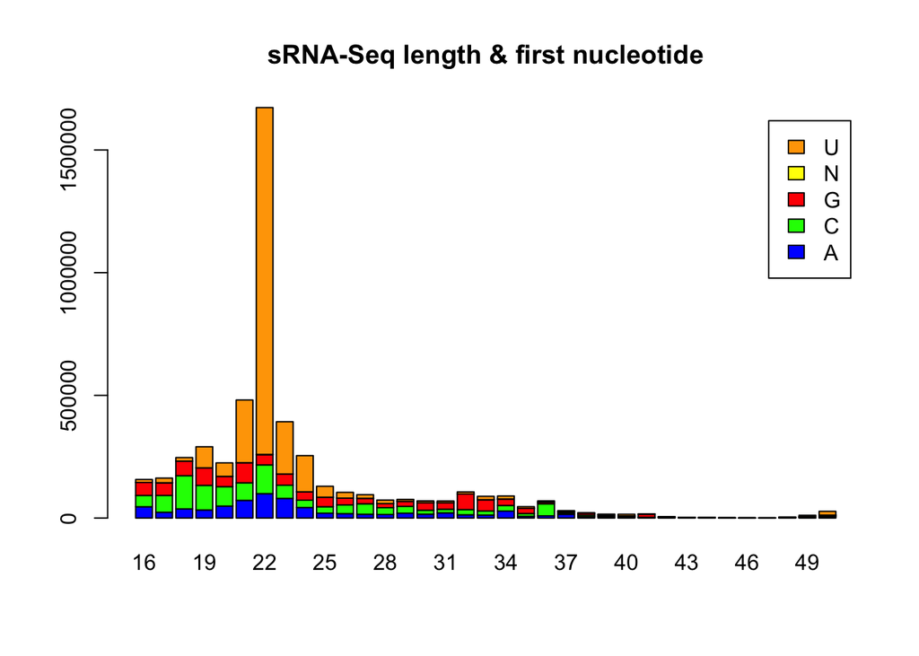

```r
barplot(m_nt, main = "sRNA-Seq length & first nucleotide", col = c("blue", "green", "red", "yellow", "orange"), legend.text = rownames(m_nt))
```

Hay varias cosas que están pasando en este gráfico.

- Barplot recibe como primer argumento un vector numérico o una matriz que contenga la información de la altura de las barras.
- el argumento main= sirve para establecer el título de la figura. Nota que el título de la figura está rodeado de comillas
- el argumento col= sirve para indicar los colores de la figura. R acepta distintos formatos para establecer colores como un vector de caracteres c(“red”, “blue”, “green”), sistema hexadecimal c(“#FF0000”, “#00FF00”), o incluso puede aceptar números y R hará una tranformación de dichos valores a un color (aunque con poco control sobre la selección de colores)
- el argumento legend= indica cuáles serán los nombres a mostrar en la leyenda, R automáticamente relacionará los nombres de la leyenda con el color correspondiente. Nosotros podemos tener un mayor control de la leyenda usando la función legend()

En la siguiente imagen utilizo números para asignar los colores a la figura. Vale la pena mencionar que la selección de colores deja bastante que desear, pero para ello existe una gran cantidad de paquetes que contienen muy buenas selecciones de colores como RColorBrewer, viridis, entre muchos más.

Algo que quiero resaltar es como a partir de muy pocas instrucciones podemos generar figuras que ya son interpretables.

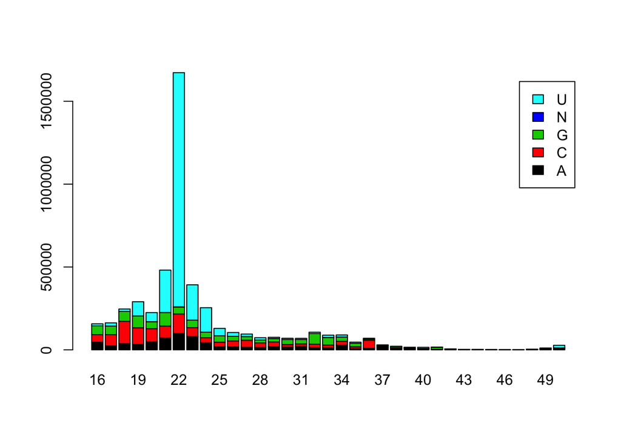

```r
barplot(m_nt, col = 1:nrow(m_nt), legend.text = rownames(m_nt))
```

Felicidades! has completado la sesión de familiarización con R

##### Resumen

En esta página aprendimos:

- Tipos de variables en R y algunas de las funciones que se pueden aplicar sobre ellas
- Leer tablas dentro de R (read.table)
- Ordenar data frames de acuerdo a los valores de una columna de interés
- Buscar relación entre variables (plot, cor, scatter.smooth)
- Leer archivos fasta dentro de R (scanFa)
- Explorar longitud de secuencias y obtener el contenido de GC (width, letterFrequency)
- Nos familizarizamos con algunas de las gráficas disponibles en R base (plot, barplot, hist, boxplot, scatter.smooth)

##### Disclaimer

Es posible que en algún punto de la sesión te hayas sentido agobiad@ con la manera de producir gráficas. Lo siento! :P

Decidí mostrar cómo algunos de los argumentos de las funciones para graficar alteran las figuras de **R base**. R tiene hoy en día una gran oferta de paquetería para graficar (ggplot2, Plotly, Lattice, etc.), sin embargo, por las dificultades que representa instalar paquetes para algunos estudiantes, opté por usar las funciones de gráficos básicos para la primera clase. De todas formas, hacer gráficas con R con cualquier paquetería tiene una curva de aprendizaje y tener figuras con la calidad necesaria para una publicación es un proceso que demanda esfuerzo y tiempo.

##### Tus comentarios y sugerencias son muy valiosos

Puedes enviar tus comentarios y sugerencias con respecto a esta práctica al correo jose.bermudez@cinvestav.mx

##### Próximamente

Próximamente abordaremos paquetes de R específicos como ggplot2, GenomicRanges, etc. Tales tutoriales estarán disponibles en: https://bbermudez.github.io/